# Regression Analysis of Bike Sharing Demand

Chance Robinson, Jayson Barker and Neha Dixit

Master of Science in Data Science, Southern Methodist University, USA

# Introduction

# Data Description

The dataset we chose for this project was a publicly shared, hourly bike sharing dataset made available through Kaggle in csv format.

This data set is divided into two distinct sets – a train and test set. The train set consists of 10,886 rows (titled “train.csv”) and the test set consists of 6,493 rows (titled “test.csv”). Within the training set, the first 19 days of each month are captured whereas in the test data set, the 20th day to the end of each month is present. The entirity of the data spans from 1/1/2011 through 12/31/2012 - encompassing two full years of bike sharing data. Interstingly, the time component of this analysis is captured in hours of each day meaning we have a calendar date represented 24 times (for each hour of that day) in the data, along with it’s associated attribute values.

In train data set, there are a total of 12 attributes which capture multiple variables related to bike rentals. Some of these attributes are categorical, and others are continuous. All attributes are summarized in the table below:

| Column Name | Type | Description |
| --- | --- | --- |
| 1. datetime | Date | YYYY-MM-DD HH24 (example: 2011-01-01 04:00:00) |
| 2. season | Integer | (1-4) |
| 3. holiday | Integer | (0 or 1) |
| 4. workingday | Integer | (0 or 1) |
| 5. weather | Integer | (1-4) |
| 6. temp | Float | temparture in Celcius |
| 7. atemp | Float | “feels like” temperature in Celsius |
| 8. humidity | Integer | relative humidity |
| 9. windspeed | Float | wind speed |
| 10. casual | Integer | count of casual users |
| 11. registered | Integer | count of registered users |
| 12. count | Integer | count of total users `response variable` |

** The test data set lacks the casual, registered and count variables.

# Exploratory Data Analysis

- Plotting Explanatory vs. Response Variables

## Categorical Variables

Several numeric variables were found to be better suited to categorization and were converted to factors.

### Season

| Season | Label | Description |
| --- | --- | --- |
| 1 | Spring | Dec 21 ~ Mar 20 |
| 2 | Summer | Mar 21 ~ Jun 20 |
| 3 | Fall | Jun 21 ~ Sep 20 |
| 4 | Winter | Sep 21 ~ Dec 20 |

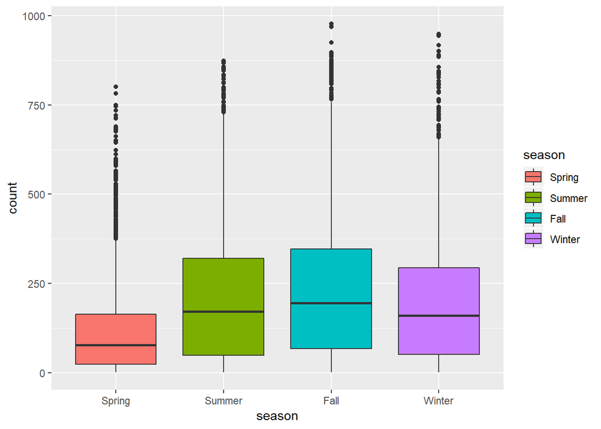

#### Holiday

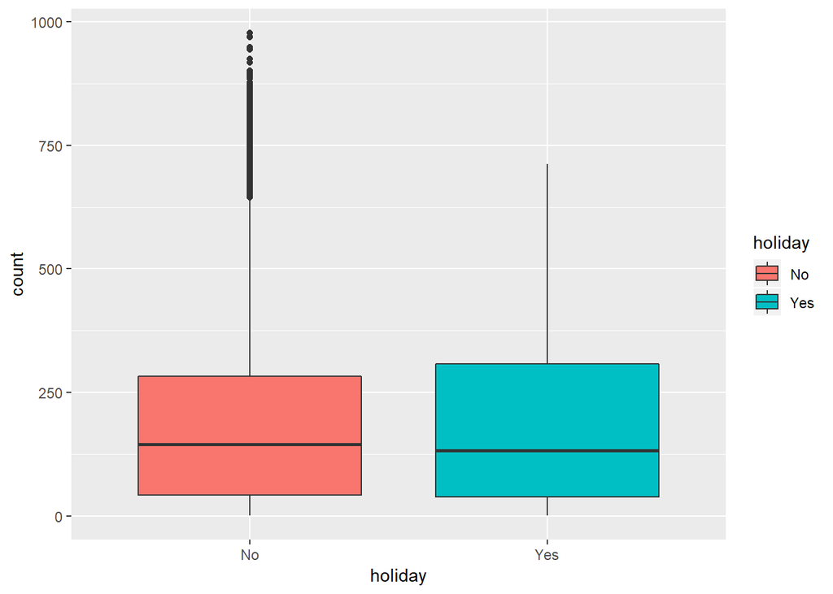

### Working Day

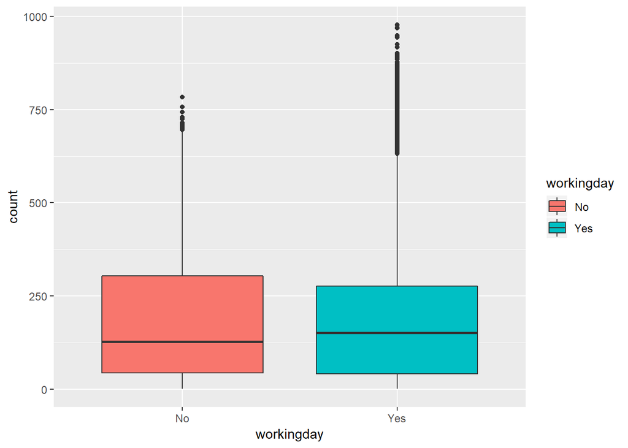

### Weather

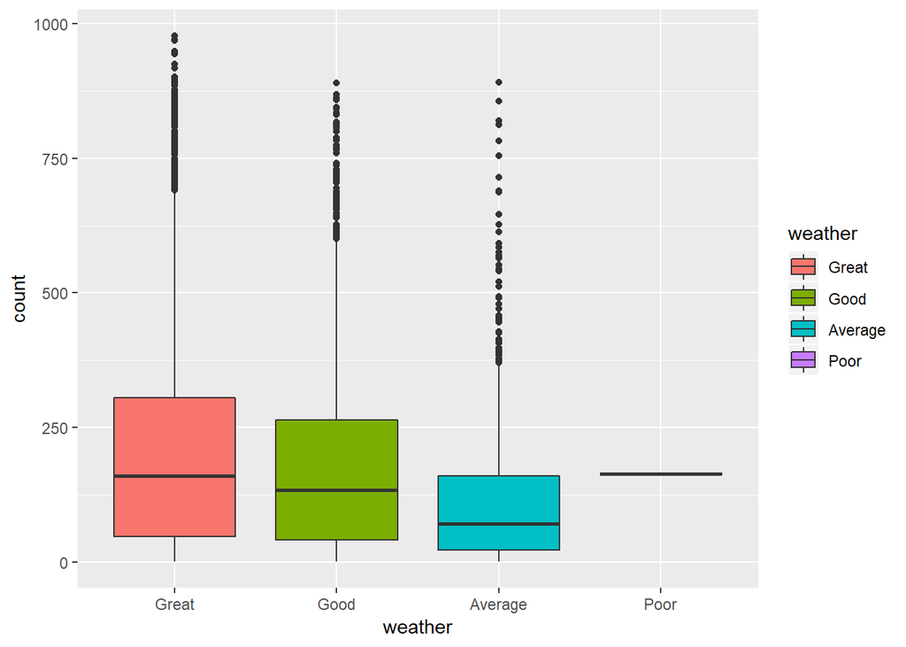

The datetime column was broken out into multiple factors as well so that we could visualize the components of each date and aggregate by different dimensions of the timestamp. We felt this was also necessary due to the nature of how the train/ test data sets had been pre-split. (i.e…with the first 19 days of the month holding the only true counts to validate our models against.)

- Year
- Month
- Day
- Hour

### Month

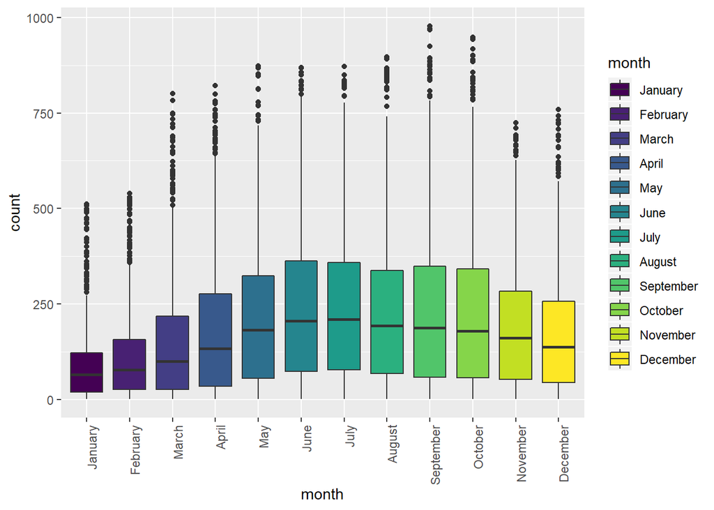

## Continuous Variables

### Count by Temperature

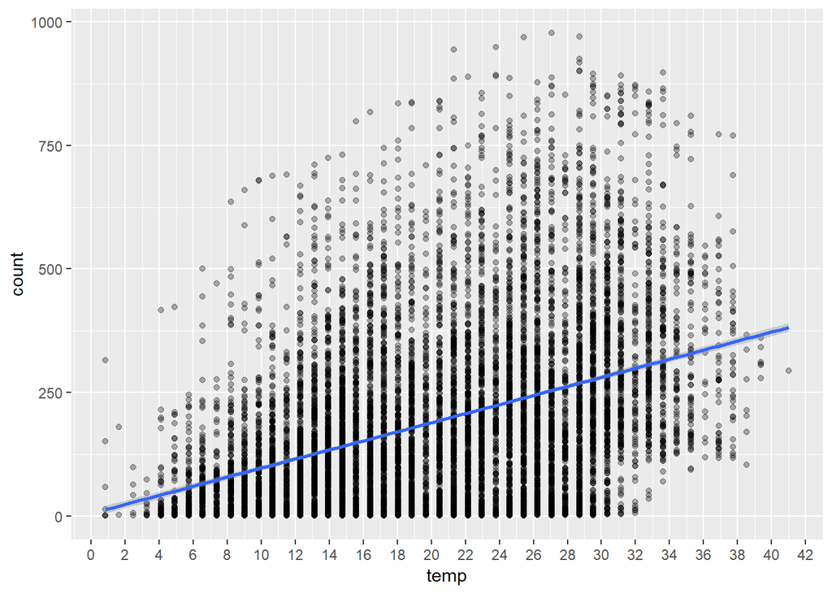

### Count by “Feels like” Temperature

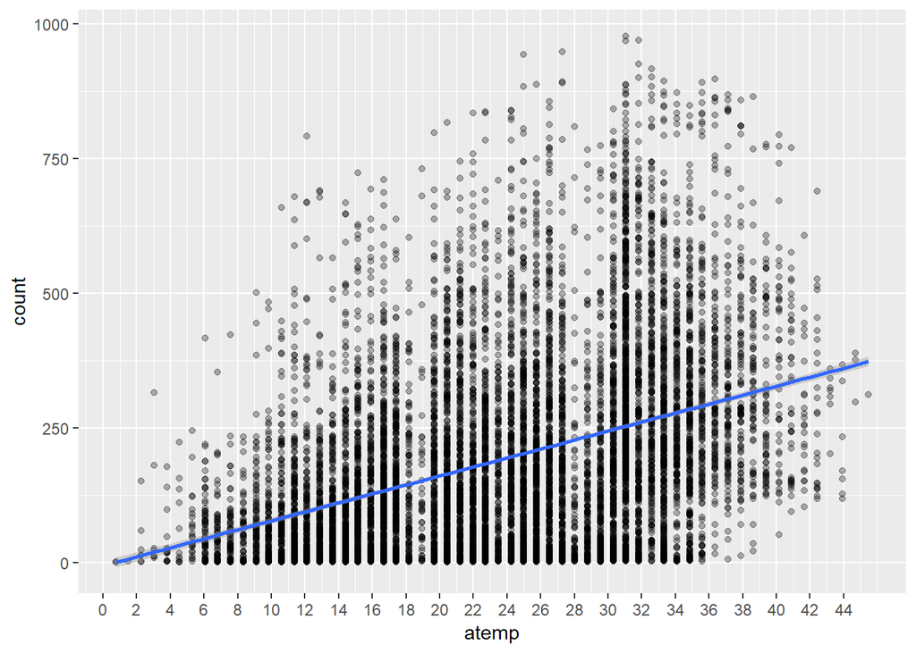

### Count by Wind Speed

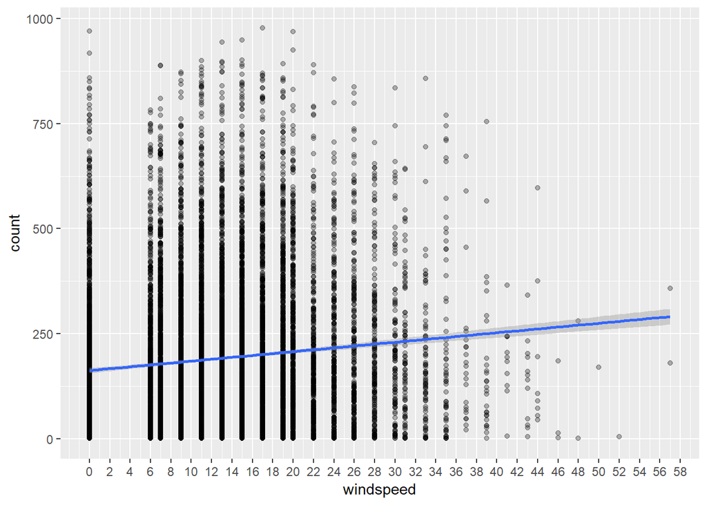

## Correlation Matrix

There are several variables with a relatively high level of covariance from the training set. The following columns should therefore be removed so as not to be picked up by any automated modelling techniques.

- atemp
- causual
- registered

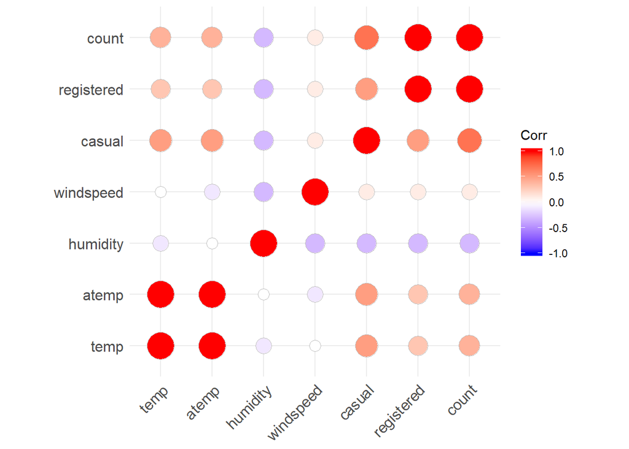

# Objective I Analysis

## Question of Interest

The team be utilizing the multiple linear regression techniques we’ve learned up to this point in the program to predict the bike rental deman on a given date and time. The model will be evaluated on the Root Mean Squared Logarithmic Error, or RMSLE. As this data represents hourly data collected, there is an obvious time component associated with this particular competition. We wanted to gauge how effective mutiple linear regression would be when the assumption of indepdence is clearly violated.

```
## # A tibble: 12 x 5
##    month      mean    sd median observations
##    <ord>     <dbl> <dbl>  <dbl>        <int>
##  1 January    3.78  1.47   4.17          884
##  2 February   3.98  1.51   4.36          901
##  3 March      4.19  1.61   4.61          901
##  4 April      4.46  1.53   4.89          909
##  5 May        4.76  1.43   5.20          912
##  6 June       4.89  1.38   5.33          912
##  7 July       4.90  1.35   5.34          912
##  8 August     4.86  1.37   5.26          912
##  9 September  4.81  1.42   5.24          909
## 10 October    4.79  1.42   5.19          911
## 11 November   4.65  1.40   5.09          911
## 12 December   4.52  1.43   4.93          912
```

```
## # A tibble: 1 x 12
##   datetime            season holiday workingday weather  temp atemp
##   <dttm>               <dbl>   <dbl>      <dbl>   <dbl> <dbl> <dbl>
## 1 2012-01-06 13:00:00      1       0          1       1  16.4  20.5
## # ... with 5 more variables: humidity <dbl>, windspeed <dbl>,
## #   casual <dbl>, registered <dbl>, count <dbl>
```

## Model Selection

### Lasso

```r
split.perc = .80

train.indices = sample(1:dim(train.mod.1)[1],round(split.perc * dim(train.mod.1)[1]))

train.mod.1.train = train.mod.1[train.indices,]
train.mod.1.test  = train.mod.1[-train.indices,]


train.mod.1.train$datetime <- NULL
train.mod.1.test$datetime <- NULL


train.mod.1.train
```

```
## # A tibble: 8,624 x 12
##    season holiday workingday weather  temp humidity windspeed count year
##    <fct>  <fct>   <fct>      <fct>   <dbl>    <dbl>     <dbl> <dbl> <fct>
##  1 Summer No      Yes        Great    29.5       39     22.0   5.91 2012
##  2 Winter No      Yes        Good     23.0       73      0     3.43 2012
##  3 Fall   No      No         Great    37.7       37     15.0   5.78 2012
##  4 Winter No      No         Good     24.6       56     28.0   6.36 2012
##  5 Winter No      Yes        Great    10.7       70      6.00  3.64 2011
##  6 Summer No      Yes        Average  15.6       94     22.0   1.10 2011
##  7 Fall   No      Yes        Great    33.6       46     22.0   5.20 2011
##  8 Spring No      Yes        Great    16.4       43     15.0   5.04 2012
##  9 Summer No      Yes        Great    26.2       78      7.00  6.22 2012
## 10 Winter No      No         Great    12.3       70      0     4.54 2012
## # ... with 8,614 more rows, and 3 more variables: month <ord>, day <fct>,
## #   hour <fct>
```

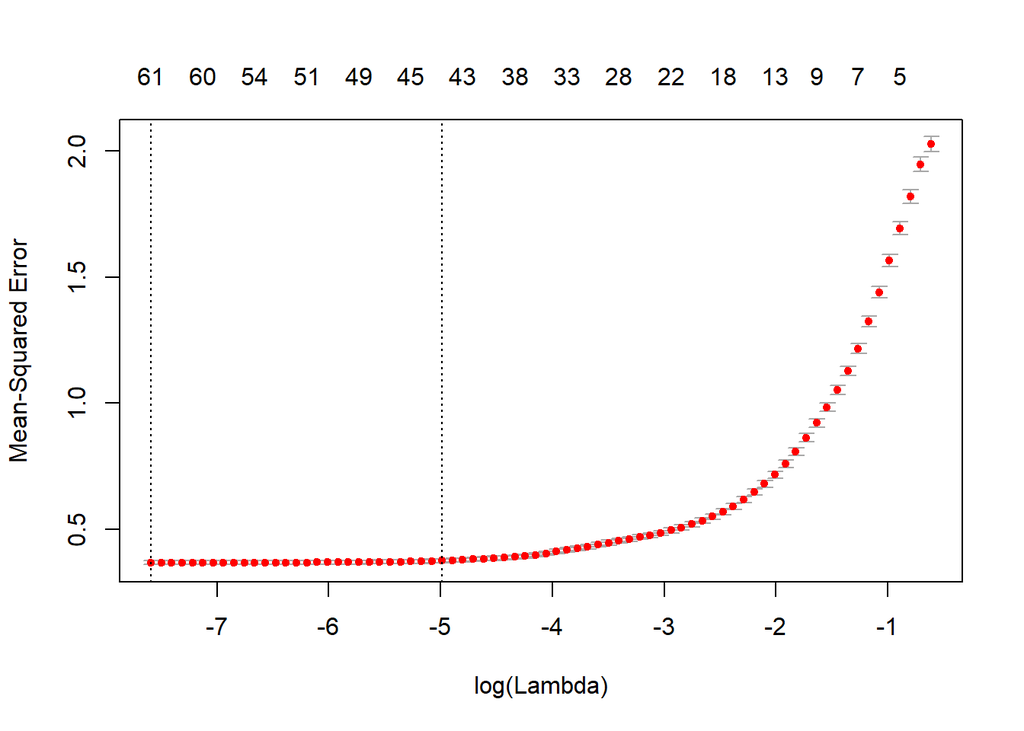

```r
x <- model.matrix(count~.,train.mod.1.train)[,-7]
y <- train.mod.1.train$count

grid=10^seq(10,-2, length =100)
lasso.model <- glmnet(x,y,alpha=1, lambda=grid)

xtest<-model.matrix(count~.,train.mod.1.test)[,-7]
ytest <- train.mod.1.test$count


cv.out=cv.glmnet(x,y,alpha=1) #alpha=1 performs LASSO
plot(cv.out)
```

```r
best.lambda <-cv.out$lambda.min  #Optimal penalty parameter.  You can make this call visually.
lasso.pred=predict(lasso.model ,s=best.lambda ,newx=xtest)

testMSE_LASSO<-mean((ytest-lasso.pred)^2)
testMSE_LASSO
```

```
## [1] 0.3688791
```

```r
# Addme - New Input - results
coef(lasso.model)[, 100]
```

```
##    (Intercept)    (Intercept)   seasonSummer     seasonFall   seasonWinter
##    3.798048546    0.000000000    0.083966436    0.000000000    0.000000000
##     holidayYes  workingdayYes weatherAverage    weatherPoor           temp
##    0.000000000   -0.040164514   -0.471980463    0.000000000    0.030438387
##       humidity      windspeed       year2012        month.L        month.Q
##   -0.004539940   -0.001688385    0.456764551    0.689294482   -0.179856773
##        month.C        month^4        month^5        month^6        month^7
##    0.044963123   -0.019549199   -0.092763035    0.000000000    0.111699055
##        month^8        month^9       month^10       month^11          day02
##    0.000000000    0.000000000    0.020135333    0.000000000    0.000000000
##          day03          day04          day05          day06          day07
##    0.000000000    0.000000000    0.000000000    0.000000000   -0.001714602
##          day08          day09          day10          day11          day12
##    0.000000000    0.000000000    0.000000000    0.000000000    0.000000000
##          day13          day14          day15          day16          day17
##    0.000000000    0.000000000    0.017868666    0.000000000    0.017599745
##          day18          day19         hour01         hour02         hour03
##    0.000000000    0.000000000   -1.112631584   -1.677781138   -2.130307273
##         hour04         hour05         hour06         hour07         hour08
##   -2.398363752   -1.408411722   -0.219590416    0.696865159    1.278794558
##         hour09         hour10         hour11         hour12         hour13
##    0.963311570    0.637827319    0.753937589    0.922860543    0.891342777
##         hour14         hour15         hour16         hour17         hour18
##    0.786156702    0.858752756    1.126624433    1.548613798    1.475831713
##         hour19         hour20         hour21         hour22         hour23
##    1.184007566    0.888534361    0.640855432    0.396517126    0.000000000
```

```r
lasso.model.reg <- lm(count ~ season + holiday + workingday + weather + temp + humidity + windspeed + year + month + day + hour, data = train.mod.1 )

summary(lasso.model.reg)
```

```
##
## Call:
## lm(formula = count ~ season + holiday + workingday + weather +
##     temp + humidity + windspeed + year + month + day + hour,
##     data = train.mod.1)
##
## Residuals:
##      Min       1Q   Median       3Q      Max
## -3.15983 -0.29334  0.03104  0.36536  2.30961
##
## Coefficients: (3 not defined because of singularities)
##                  Estimate Std. Error t value Pr(>|t|)
## (Intercept)     3.4146388  0.0825232  41.378  < 2e-16 ***
## seasonSummer   -0.1933567  0.0825278  -2.343  0.01915 *
## seasonFall     -0.1908323  0.0870006  -2.193  0.02830 *
## seasonWinter   -0.0822135  0.0802693  -1.024  0.30575
## holidayYes     -0.0651595  0.0367882  -1.771  0.07655 .
## workingdayYes  -0.0756853  0.0128948  -5.869 4.50e-09 ***
## weatherGood    -0.0566339  0.0144020  -3.932 8.46e-05 ***
## weatherAverage -0.5468535  0.0243571 -22.452  < 2e-16 ***
## weatherPoor    -0.1153001  0.6028021  -0.191  0.84831
## temp            0.0264714  0.0017962  14.738  < 2e-16 ***
## humidity       -0.0033270  0.0004226  -7.872 3.81e-15 ***
## windspeed      -0.0038725  0.0007785  -4.974 6.64e-07 ***
## year2012        0.4843297  0.0117903  41.079  < 2e-16 ***
## month.L         0.7933327  0.0995054   7.973 1.71e-15 ***
## month.Q        -0.5677229  0.1103000  -5.147 2.69e-07 ***
## month.C         0.1356652  0.0454261   2.987  0.00283 **
## month^4         0.0603546  0.0471898   1.279  0.20093
## month^5        -0.2018698  0.0512998  -3.935 8.37e-05 ***
## month^6         0.0464196  0.0274472   1.691  0.09082 .
## month^7         0.1728374  0.0325262   5.314 1.10e-07 ***
## month^8        -0.1144967  0.0420091  -2.726  0.00643 **
## month^9                NA         NA      NA       NA
## month^10               NA         NA      NA       NA
## month^11               NA         NA      NA       NA
## day02           0.0057954  0.0357192   0.162  0.87111
## day03           0.0149902  0.0358041   0.419  0.67546
## day04           0.0300391  0.0359022   0.837  0.40278
## day05           0.0208216  0.0356974   0.583  0.55972
```

[output cut: 28 more lines]

```
## hour15          1.5070285  0.0414147  36.389  < 2e-16 ***
## hour16          1.7689445  0.0413159  42.815  < 2e-16 ***
## hour17          2.1817238  0.0410738  53.117  < 2e-16 ***
## hour18          2.0972394  0.0408025  51.400  < 2e-16 ***
## hour19          1.8038942  0.0403577  44.698  < 2e-16 ***
## hour20          1.5033515  0.0401294  37.463  < 2e-16 ***
## hour21          1.2437505  0.0399661  31.120  < 2e-16 ***
## hour22          0.9997447  0.0398943  25.060  < 2e-16 ***
## hour23          0.5990908  0.0398620  15.029  < 2e-16 ***
## ---
## Signif. codes:  0 '***' 0.001 '**' 0.01 '*' 0.05 '.' 0.1 ' ' 1
##
## Residual standard error: 0.6009 on 10718 degrees of freedom
## Multiple R-squared:  0.8235, Adjusted R-squared:  0.8225
## F-statistic:   820 on 61 and 10718 DF,  p-value: < 2.2e-16
```

```r
AIC(lasso.model.reg)
```

```
## [1] 19676.45
```

```r
BIC(lasso.model.reg)
```

```
## [1] 20135.43
```

```r
RMSE <- function(error) { sqrt(mean(error^2)) }
RMSE(lasso.model.reg$residuals)
```

```
## [1] 0.5992083
```

### Custom Variable Selection

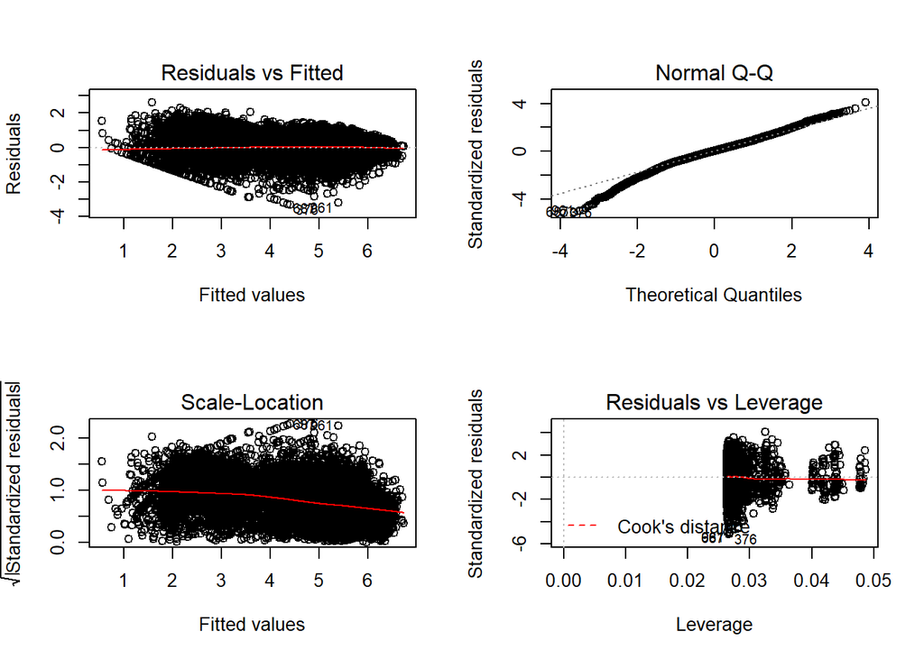

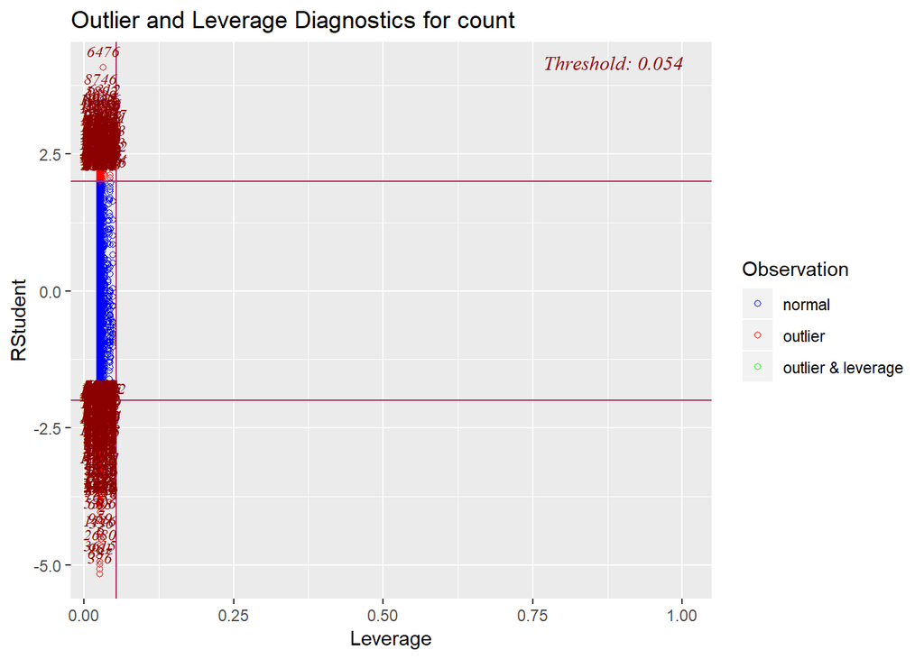

```
##
## Call:
## lm(formula = custom.model.formula, data = train.mod.1)
##
## Residuals:
##     Min      1Q  Median      3Q     Max
## -3.3106 -0.3711  0.0243  0.3997  2.6134
##
## Coefficients:
##                   Estimate Std. Error t value Pr(>|t|)
## (Intercept)      3.0514264  0.0485396  62.865  < 2e-16 ***
## weatherGood     -0.0892246  0.0147807  -6.037 1.63e-09 ***
## weatherAverage  -0.6658679  0.0240554 -27.681  < 2e-16 ***
## weatherPoor      0.0588797  0.6602365   0.089 0.928941
## windspeed       -0.0030596  0.0008236  -3.715 0.000204 ***
## temp             0.0393301  0.0019319  20.359  < 2e-16 ***
## month.L          0.7622274  0.1071611   7.113 1.21e-12 ***
## month.Q         -0.2701100  0.1130316  -2.390 0.016880 *
## month.C          0.1188636  0.1066572   1.114 0.265114
## month^4          0.0815800  0.1066398   0.765 0.444286
## month^5         -0.0875537  0.1060760  -0.825 0.409171
## month^6         -0.1487951  0.1057656  -1.407 0.159505
## month^7          0.2558154  0.1057305   2.420 0.015559 *
## month^8         -0.0235189  0.1057030  -0.223 0.823929
## month^9          0.0748263  0.1056811   0.708 0.478937
## month^10         0.0483527  0.1056835   0.458 0.647304
## month^11        -0.1110268  0.1057069  -1.050 0.293592
## hour01          -0.6231655  0.0433471 -14.376  < 2e-16 ***
## hour02          -1.1278437  0.0438427 -25.725  < 2e-16 ***
## hour03          -1.6204275  0.0448758 -36.109  < 2e-16 ***
## hour04          -1.9130624  0.0453645 -42.171  < 2e-16 ***
## hour05          -0.9219430  0.0436253 -21.133  < 2e-16 ***
## hour06           0.2920075  0.0433971   6.729 1.80e-11 ***
## hour07           1.2796175  0.0433153  29.542  < 2e-16 ***
## hour08           1.9069045  0.0432438  44.097  < 2e-16 ***
## hour09           1.5811791  0.0432699  36.542  < 2e-16 ***
## hour10           1.2559008  0.0433572  28.966  < 2e-16 ***
## hour11           1.3765461  0.0435147  31.634  < 2e-16 ***
## hour12           1.5664505  0.0436851  35.858  < 2e-16 ***
## hour13           1.5405655  0.0439140  35.081  < 2e-16 ***
```

[output cut: 254 more lines]

```
## month.C:hour23   0.0102879  0.1499014   0.069 0.945285
## month^4:hour23  -0.0516577  0.1497456  -0.345 0.730124
## month^5:hour23  -0.0243869  0.1495979  -0.163 0.870509
## month^6:hour23  -0.0164262  0.1494997  -0.110 0.912511
## month^7:hour23  -0.0725439  0.1494626  -0.485 0.627428
## month^8:hour23  -0.0526880  0.1494674  -0.353 0.724466
## month^9:hour23  -0.0407292  0.1494519  -0.273 0.785225
## month^10:hour23 -0.0059807  0.1494438  -0.040 0.968078
## month^11:hour23  0.0825528  0.1494516   0.552 0.580706
## ---
## Signif. codes:  0 '***' 0.001 '**' 0.01 '*' 0.05 '.' 0.1 ' ' 1
##
## Residual standard error: 0.6514 on 10487 degrees of freedom
## Multiple R-squared:  0.7971, Adjusted R-squared:  0.7915
## F-statistic: 141.1 on 292 and 10487 DF,  p-value: < 2.2e-16
```

```
## [1] 21642.12
```

```
## [1] 23784.04
```

```
## [1] 0.6424911
```

### Stepwise

```
## # A tibble: 6 x 10
##   datetime            season holiday workingday weather  temp atemp
##   <dttm>               <dbl>   <dbl>      <dbl>   <dbl> <dbl> <dbl>
## 1 2011-01-20 00:00:00      1       0          1       1 10.7   11.4
## 2 2011-01-20 01:00:00      1       0          1       1 10.7   13.6
## 3 2011-01-20 02:00:00      1       0          1       1 10.7   13.6
## 4 2011-01-20 03:00:00      1       0          1       1 10.7   12.9
## 5 2011-01-20 04:00:00      1       0          1       1 10.7   12.9
## 6 2011-01-20 05:00:00      1       0          1       1  9.84  11.4
## # ... with 3 more variables: humidity <dbl>, windspeed <dbl>, count <dbl>
```

```
##
## Call:
## lm(formula = stw.model.formula, data = train.mod.1)
##
## Residuals:
##      Min       1Q   Median       3Q      Max
## -3.15360 -0.29298  0.03005  0.36343  2.28184
##
## Coefficients:
##                  Estimate Std. Error t value Pr(>|t|)
## (Intercept)     3.3185466  0.0543002  61.115  < 2e-16 ***
## hour01         -0.6283497  0.0400037 -15.707  < 2e-16 ***
## hour02         -1.1381656  0.0404168 -28.161  < 2e-16 ***
## hour03         -1.6624716  0.0411662 -40.384  < 2e-16 ***
## hour04         -1.9331478  0.0414364 -46.653  < 2e-16 ***
## hour05         -0.9284280  0.0402859 -23.046  < 2e-16 ***
## hour06          0.2875110  0.0401026   7.169 8.03e-13 ***
## hour07          1.2729308  0.0399964  31.826  < 2e-16 ***
## hour08          1.9012631  0.0399124  47.636  < 2e-16 ***
## hour09          1.5738878  0.0399476  39.399  < 2e-16 ***
## hour10          1.2465061  0.0401065  31.080  < 2e-16 ***
## hour11          1.3659832  0.0403947  33.816  < 2e-16 ***
## hour12          1.5543499  0.0407221  38.170  < 2e-16 ***
## hour13          1.5290219  0.0410736  37.226  < 2e-16 ***
## hour14          1.4466055  0.0413441  34.989  < 2e-16 ***
## hour15          1.5052526  0.0414216  36.340  < 2e-16 ***
## hour16          1.7671746  0.0413238  42.764  < 2e-16 ***
## hour17          2.1802206  0.0410840  53.067  < 2e-16 ***
## hour18          2.0959057  0.0408151  51.351  < 2e-16 ***
## hour19          1.8028402  0.0403731  44.654  < 2e-16 ***
## hour20          1.5026946  0.0401467  37.430  < 2e-16 ***
## hour21          1.2432966  0.0399844  31.095  < 2e-16 ***
## hour22          0.9994465  0.0399131  25.041  < 2e-16 ***
## hour23          0.5991429  0.0398810  15.023  < 2e-16 ***
## month.L         0.7000644  0.0246475  28.403  < 2e-16 ***
## month.Q        -0.3390579  0.0425804  -7.963 1.85e-15 ***
## month.C         0.1248745  0.0217872   5.732 1.02e-08 ***
## month^4        -0.0322583  0.0226045  -1.427 0.153588
## month^5        -0.1711469  0.0210764  -8.120 5.16e-16 ***
## month^6         0.0058195  0.0202815   0.287 0.774167
## month^7         0.1614066  0.0204057   7.910 2.83e-15 ***
## month^8        -0.0330721  0.0201662  -1.640 0.101040
## month^9        -0.0205367  0.0201303  -1.020 0.307662
## month^10        0.0446787  0.0201415   2.218 0.026559 *
## month^11       -0.0053141  0.0200319  -0.265 0.790798
## year2012        0.4838918  0.0117934  41.031  < 2e-16 ***
## weatherGood    -0.0552635  0.0143445  -3.853 0.000118 ***
## weatherAverage -0.5514934  0.0242995 -22.696  < 2e-16 ***
## weatherPoor    -0.1033689  0.6026033  -0.172 0.863805
## temp            0.0267512  0.0017862  14.977  < 2e-16 ***
## humidity       -0.0033142  0.0004201  -7.890 3.32e-15 ***
## workingdayYes  -0.0762272  0.0128698  -5.923 3.26e-09 ***
## windspeed      -0.0036758  0.0007754  -4.741 2.16e-06 ***
## holidayYes     -0.0631797  0.0363670  -1.737 0.082366 .
## ---
## Signif. codes:  0 '***' 0.001 '**' 0.01 '*' 0.05 '.' 0.1 ' ' 1
##
## Residual standard error: 0.6012 on 10736 degrees of freedom
## Multiple R-squared:  0.8231, Adjusted R-squared:  0.8224
## F-statistic:  1161 on 43 and 10736 DF,  p-value: < 2.2e-16
```

```
## [1] 19668.86
```

```
## [1] 19996.7
```

```
## [1] 0.5999985
```

## Model Assumptions Assessment

- The response variable is linear
- The data is normally distributed
- Independence

## Conclusion

# Objective II Analysis

## Question of Interest

**Time-Series Analysis**

## Model Assumption Assessment

[output not shown]